# Kapitel 8 Bipolär sjukdom

## 8.1 Inledning

Bipolärt syndrom innebär episoder med mani eller hypomani samt (i de flesta fall) återkommande depressioner. Vid mani föreligger både ökad aktivitet (eller -energi) och förändrat stämningsläge (förhöjt, expansivt eller irritabelt).

Man brukar tala om ett “bipolärt spektrum” som har kontinuitet till normala variationer i humör, energi och beteende, men även spektrum inom bipolaritet (=svårighetsgrad?). Ca 1/3 av de med cyklotymi (hypomana och depressiva perioder i minst två år utan att uppfylla de fulla kriterierna för egentlig depression, hypomani eller mani) och liknande besvär utvecklar bipolärt syndrom. Notera att om spektrumbegreppet drivs för långt blir det meningslöst och riskerar att beteckna det normala som patologiskt [95].

### 8.1.1 Historik

Emil Kraepelin beskrev manodepressiv sjukdom, där han inkluderade “periodiskt och cirkulärt vansinne”, “enkel mani”, huvudperten av melankoli, och “amenti” (konfusionellt vansinne). Beskrivningar av bipolaritet finns redan från antiken, där exempelvis Soranus av Efesos skrev att “Themisons följare, liksom många andra, anser melankoli vara en form av sjukdomen mani.” [95]

Kraepelin delade in sinnessjukdom i två huvudgrupper, manodepressivt vansinne och dementia praecox (schizofreni), där den första gruppen kännetecknades av ett episodiskt förloppet, en mer godartad prognos, och ärflighet för manodepressiv sjukdom. I motsats såg Bleuler dessa två grupper som del av ett spektrum och indelade manodepressiv sjukdom i undergrupper. Han använde bland annat begreppet “affektiv sjukdom” [95 ff].

På 1950-talet föreslog Leonhard en indlningen i “bipolär” (för personer med depression och mani) och “monopolär” (återkommande depression). Man fann på 1960-talet att ärftlighet för bipolär sjukdom skiljde dessa två kategorier åt.

### 8.1.2 Epiedmiologi

Tabell Livstidsprevalens bipolärt spektrum [96,97]

| Syndrom | % | kumulativt |
| --- | --- | --- |
| Bipolär I | 0.6 | 0.6 |
| Bipolär II | 0.4 | 1.0 |
| Subsyndromal | 1.4 | 2.4 |

Bipolär II vanligare hos kvinnor.

#### 8.1.2.1 Ärftlighet

*Heritabiliteten* (förekomst som ej förklaras av slumpen) är ca 70 % (BPI ~ BPII) Dvs förekomst av bipolärt syndrom som EJ förklaras av omgivningsfaktorer eller slumpen [95]. Ca 20 % har BP i familjen. Livstidsrisken för släktingar ca 10 % (BPI eller II). Även ökad risk för egentlig depression [95].

**Tabell: Konkordans för tvillingpar**

| Typ | Enäggs | Tvåäggs |
| --- | --- | --- |
| BPI | 80 % | 13 % |
| BPII | 78 % | 31 % |
| MDD | 54 % | 24 % |

#### 8.1.2.2 Prognos och förlopp

Mani återkommer hos 90 %. Depression är den främsta sjukdomsbördan vid bipolärt syndrom. Kvinnor med bipolär sjukdom har större inslag depression än män. Ca 60-70% av maniska och hypomaniska episoder uppträder i anslutning till (före eller efter) en depressiv episod. Längre tid till start av behandling förknippat med sämre prognos [95,96]. Högre antal episoder är förknippat med längre duration av- och svårare efterföljande episoder [97]. Över livstiden får vissa progress av sjukdomen minskande intervall mellan episoder och minskande behandlingsrespons [95]. Upprepade skov är hos en subgrupp förknippat med progress i form av minskad volym grå hjärnsubstans, tilltagande kognitiva besvär, mer residualsymtom mellan episoder, svårare skov, minskad respons på behandling. Tidig underhålllsbehandling behandling, särskilt när den medför episodfrihet, reverserar kognitiva besvär och hjärnplasticitet [97].

Nästan alla med BP behöver förebyggande behandling för att minska antal skov, residualsymtom, och återhämta funktionsnivå och livskvalitet. Med behandling får ca 19-25% ett återfall vaje år, jämfört med 23%-40% för dem med placebobehandling [97].

Personer med täta depressiva skov liknar bipolärt syndrom i fråga om hereditet, debutålder, atypiska symtom och profylaktisk respons på litium.

Notation: Mönstret hos en individ med bipolärt syndrom kan vara övervägande svåra maniska skov, och mindre svåra depressioner, eller tvärtom, och kan noteras som Md respektide mD, där mD motsvarar ungefär bipolär II (emedan md kan motsvara cyclotymi) [95].

Vissa patienter (ca 50%) har en återkommande ordning i vilket mani följs av depression (MDI) eller tvärtom (DMI)[98]:

- MDI (sequence mania-depression-free interval)
- DMI (sequence depression-mania-free interval)
- CC-LC (continuous circular course with long cycles)
- CC-RC (continuous circular course with rapid cycles)
- IRR (irregular course).

Kategorisering i dessa mönster kan eventuellt förutsäga rspons på litium[99,100].

> Responsiveness to lithium (and alternative treatments) has been inferior among patients with relatively complicated forms of bipolar disorder, such as with rapid-cycling, psychotic features, co-occurring anxiety syndromes or substance-abuse, as well as in depression-prone cases or those following the DMI course pattern, and lithium is less effective in preventing recurrences of bipolar depression than mania. Importantly, the same limitations hold true for alternative treatments, including anticonvulsants and modern antipsychotics[100].

Tidig debut med psykotisk depression är kopplat till ökad risk för senare manisk episod. Stämningsinkongruenta psykotiska symtom är förknippat med sämre prognos, kan vara mer likt schizofreni [95]?

##### 8.1.2.2.1 Suicidrisk

Suicidrisken är x 10-30 jämfört med befolkningen. ~ 1/3 gör su-försök under livstiden. ~ 10 % dör av suicid. Suicidrisk och funktionsnedsättning BP1 ~ BP2. Manligt kön, och suicid hos förstagradssläkting är prediktorer för suicid [97]. Perioden under- (14% av suicid) och inom sex veckor (26%) efter sjukhusinläggning innebär ökad risk. > 70% av suicid och -försök sker under depressiva episoder, särskilt ökad risk vid blandade episoder. Det bör här beaktas att en manisk episod kan följas av en depressiv-. Förgiftning är den vanligaste suicidmetoden. [97]

#### 8.1.2.3 Sjukdomsbörda för individen

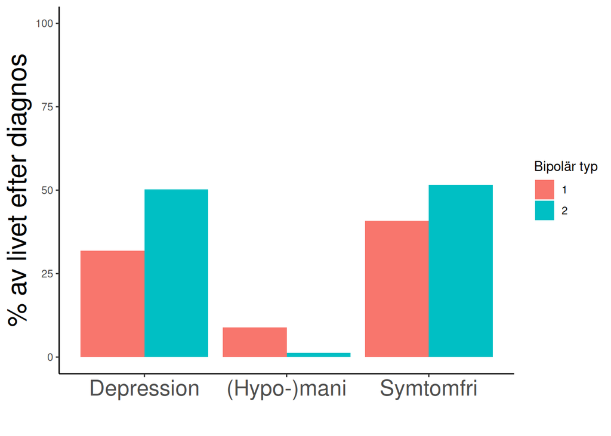

Subsyndromalt 3 ggr vanligare än syndromalt.

Antal episoder (any) per år = 0.4 (SD 0.3)[101]. Mediantiden i sjukdom (any) är 23%[101]. Ca 80-90% återhämtar sig inom två år från en episod[101].

Tabell: Tid till återhämtning (veckor vid olika percentiler) efter olika typer av bipolära episoder[101]

| Typ | N episoder | 25% | 50% | 75% |
| --- | --- | --- | --- | --- |
| Major depression | 373 | 6 | 15 | 35 |
| Minor depression | 157 | 3 | 7 | 15 |
| Mania | 246 | 4 | 7 | 15 |
| Hypomania | 126 | 2 | 3 | 6 |
| Major cycling | 182 | 21 | 42 | 111 |
| Mixed major cycling | 94 | 25 | 61 | 368 |
| Minor cycling | 28 | 9 | 13 | 35 |
| Mixed major cycling | 2 | 7 | 7 | 76 |

> Major cycling was defined as alternating periods of depression (major depression or minor depression) and mood elevation (mania or hypomania), immediately contiguous with each other or separated by less than 8 consecutive weeks with euthymia. In addition, at least 1 major pole (major depression or mania) was present at some point during the episode. Mixed major cycling was defined as an episode of major cycling that at some point also included a mixed state, ie, a period with concurrent depression and mood elevation. (These mixed states were distinguished from and not synonymous with the mixed episodes defined earlier). Minor cycling was defined as alternating periods of hypomania and minor depression, immediately contiguous with each other or separated by less than 8 consecutive weeks with euthymia[101].

> Overall, across the entire set of these first 5 mood episodes, 25% of the subjects recovered within 5 weeks of onset of the episode (ie, the first quartile), 50% of the subjects recovered within 13 weeks of onset (ie, the median), and 75% recovered within 38 weeks (ie, the third quartile)[101].

#### 8.1.2.4 Sjukdomsbörda i samhället

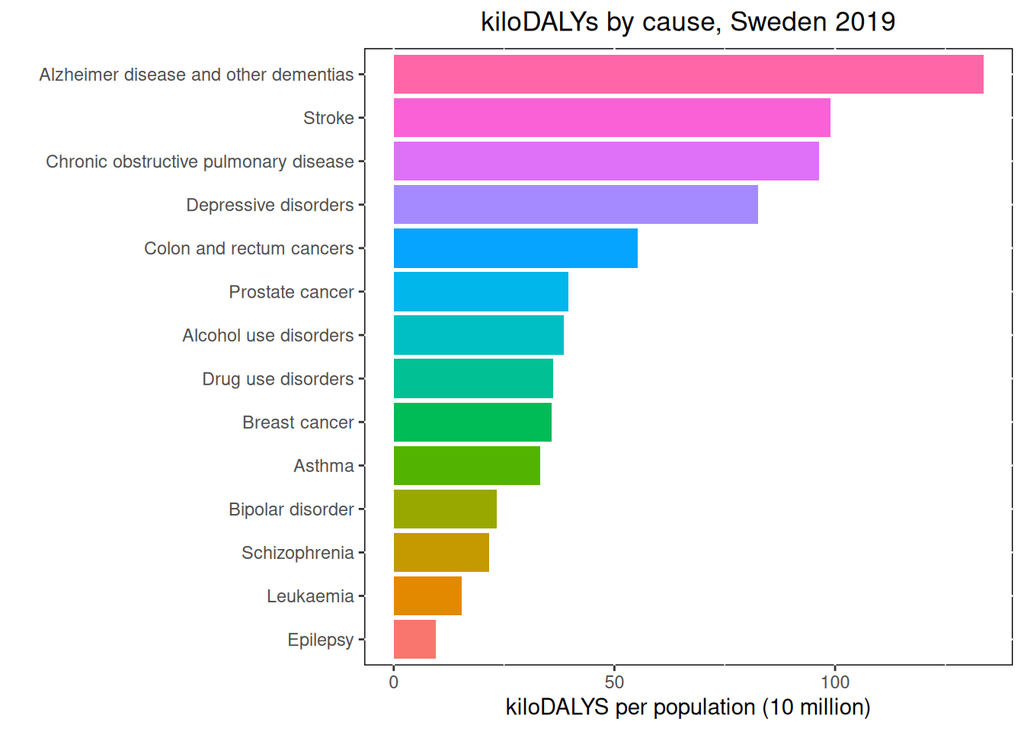

## 8.2 Diagnostik

Goodwin kritiserar att man i DSM-systemet fokuserar mer på polaritet än förlopp, och att den variant av unipolär depression som är frekvent återkommande därmed inte uppmärksammas [95]. I DSM kommer därför gruppen med “unipolär” depression att vara mer heterogen än tidigare indelningar. Tidigare krävdes för diagnos BP II (och I) mer strikt en affektiv episod med sådan svårighet att den krävde hospitalisering [95].

### 8.2.1 Diagnostik enligt DSM

Huvudkriteriet för diagnosen bipolär sjukdom är förekomst av mani (vid typ I) eller hypomani (vid typ II). Episoder med depression är inte obligat, men vanligt, och särskilt framträdande vid typ II. Diagnosen bipolär sjukdom typ I kan ställas om personen haft en eller flera maniska episoder under sin livstid, oavsett om depressiva episoder förekommit. Om hypomani förkommit men aldrig mani, samt minst en depression, ställs diagnosen bipolär sjukdom typ II. Ett förlopp med många lindriga hypomanier och lindriga depressioner under minst två år kan beskrivas som “cyklotymi”.

Bipolär sjukdom typ I kan karakteriseras vidare exemplevis baserat på svårighetsgrad (mild, måttlig, svår med/utan psykos), grad av remission (partiell eller full remission), förlopp (“rapid cycling” innebär 4 eller fler episoder under 12 månader), och typ av pågående episod (mani, hypomani, depression, blandad).

#### 8.2.1.1 Manisk episod

En manisk episod innebär att stämningsläget är förhöjt, *expansivt* eller irritabelt tillsammans med ökad energi eller *målinriktad aktivitet*. Mani bör misstänkas hos desorganiserad patient med psykomotorisk agitation [95, kap 17]. Differentialdiagnoser inkluderar drogpåverkan, delirium, och schizofreni.

För att betraktas som en manisk episod krävs att förändringen i stämningsläge och aktivitet är ihållande (föreligger nästan varje dag och större delen av dagen) under en tydligt avgränsad period (dvs inte ett varaktigt beteende) som varar minst en vecka. Om besvären är så påtagliga att de leder till sjukhusinläggning kan perioden dock vara kortare (ingen nedre gräns) och ändå räknas som en manisk episod.

Dessutom krävs att tre eller fler av följande symtom föreligger (samtidigt som förändringen i stämningsläge och -aktivitet):

- Uppblåst självförtroende eller *grandiositet*
- Minskat sömnbehov
- Ökad pratsamhet
- *Tankeflykt* eller en känsla av att tankarna rusar
- Distraherbarhet (av yttre ovidkommande stimuli)
- Ökat målinriktat beteende (tex på arbete, skola, socialt, sexuellt, ofta flera projekt samtidigt) eller psykomotorisk agitation
- Överdrivet högriskbeteende (tex ekonomiskt, sexuellt).

Notera att snabba växlingar i humöret kan förekomma (tex mellan dysfori, eufori och irritabilitet). Ökat målinriktat beteende består ofta i överdrivet planerande av- och deltagande i flera aktiviteter, exempelvis vidlyftiga projekt inom områden där personen saknar specifik kompetens. Minskat sömnbehov innebär att personen känner sig utvilad trots minskad sömntid. Uppblåst självförtroende kan vara av vanföreställningskaraktär.

Mani innebär sammanfattningsvis en tydligt avgränsad period med både…

1. **Ökad aktivitet** (eller -energi) och
2. **Förändrat stämningsläge**, något av:
- Förhöjt: Mår överdrivet bra.
- Expansivt: Uppblåst självkänsla, överdrivna beteenden (tex entusiasm, vänlighet).
- Irritabelt: Blir lätt irriterad eller arg.
3. Ett antal andra symtom (enligt ovan) föreligger.
- Stämningsläget och beteendet är:
  - Tydligt onormalt
  - Förändrat under hela perioden
    - Dvs det försvinner inte från timme till timme eller dag till dag
    - …men kan växla i karaktär (tex upprymd, arg, ångestfylld)
    - Håller i sig en vecka eller mer med symtom större delen av tiden.

#### 8.2.1.2 Hypomani

Vid hypomani saknas uttalad nedsättning av social funktion eller arbetsförmåga, vilket är den huvudsakliga skillnaden jämfört med mani. Minsta varaktigheten är då fyra dagar. Om psykotiska symtom föreligger eller om symtomen leder till sjukhusinläggning räknas episoden som mani. Beteendet skall inte förklaras bättre av psykossjukdom eller vara en effekt av droger.

#### 8.2.1.3 Rapid cycling

Minst fyra hypomaniska, maniska eller depressiva episoder (som uppfyller de fulla kriterierna) det senaste 12 månaderna. Episoder avgränsas av antingen symtomfrihet i minst två månader eller övergång till motsatt polaritet. Är associerat med substansbrukssyndrom, hypothyroidism, antidepressiva. Förekomst av rapid cycling har möjligen betydelse för val av behandling. Glöm ej undersöka thyroideastatus.

> The concept of “rapid cycling” (RC) was proposed nearly five decades ago by (Dunner and Fieve 1974) to describe bipolar manic-depressive patients with an inferior prophylactic response to lithium treatment and an episode recurrence rate of at least four/year. The criterion of four mood episodes to describe these difficult-to-treat patients was chosen arbitrarily to obtain sufficiently large samples to study (Dunner et al. 1977)[102].

En studie av 1261 personer med BP fann livstidsrisk 9% för rapid cycling, samt att endast 20% av dessa återföll i RC därefter[102]. Förekomst av RC är vanligare vid BPII, DMI-mönster, och hos kvinnor[102]. Personer med RC har sämre effekt av läkemedelsbehandling. Notera att gränsen på fyra episoder per år är arbiträr.

> We also found no association of thyroid functioning and RC, though such an association has been proposed (Bauer et al. 1990; Sack et al. 1988) though not always supported (Wehr et al. 1988; Maj et al. 1994; Post et al. 1997). In general, it remains unclear whether hypothyroidism can predispose to RC-BD or whether treatment of BD with thyroid-altering agents such as lithium can contribute to risk of RC (Carvalho et al. 2014; Buoli et al. 2017), although there is support for selective therapeutic benefits of L-thyroxine for RC-BD (Gyulai et al. 2018)[102].

#### 8.2.1.4 Med melankoliska drag

Enligt DSM definieras detta när:

- Något av följande två drag föreligger under den svåraste delen av den aktuella episoden:
  - Avsaknad av lust för nästan alla aktiviteter.
  - Avsaknad av resons på lustfyllda stimuli (ingen känsla av förbättring nör något bra händer).
- Minst tre av följande föreligger:
  - Distinkt känsla av nedstämt humör karakteriserat av hopplöshet eller tomhet.
  - Depression som regelbundet är värre på morgonen.
  - Tidigt morgonuppvaknande (monst tvp tim tidigare än vanligt)
  - Uttalad psykomotorisk hämning.
  - Påtaglig anorexi eller viktförlust.
  - Överdrivna eller omotiverade skuldkänslor.

#### 8.2.1.5 Med atypiska drag

Specificeras enligt DSM när atypiska drag dominerar de flesta dagar under episoden.

- Humöret ljusnar vid positiva händelser, samt minst två av:
  - Påtaglig viktuppgång eller ökad aptit.
  - Hypersomni.
  - “Leaden paralysis” (tung, blyliknande känsla i arma och ben).
  - Långvarigt mönster (ej endast under affektiva skov) av käslighet för interpersonellt avståndstagande som orsakar signifikant social eller yrkesmässig funktionsnedsättning.

#### 8.2.1.6 Med psykotiska drag

När vanföreställningar eller hallucinationer föreligger under någon del av episoden.

Stämningskongruenta psykotiska drag: under maniska episoder är samtliga vanföreställningar och hallucinationer överensstämmande med typiska maniska teman (grandiositet, osårbarhet etc), men kan även inkludera misstänksamhet eller paranoia, särskilt avseende ifrågasättande av personens förmågor.

Sämningsinkongruenta psykotiska drag: Innehållet överensstämmer ej med episodens polaritet, eller det föreligger en blandning av stämningskongruenta och -inkongruenta teman.

#### 8.2.1.7 Med katatoni

Uttalad motorisk störning (minskad, ökad, överdriven eller märklig motorisk aktivitet). Individen kan växla mellan minskad- och ökad aktivitet. Kan uppträda vid olika psykiatriska och neurologiska tillstånd samt orsakas av läkemedel.

Vid bipolär mani eller depression skall symtomen föreligga under större delen av episoden för att specificeras som mani/depression med katatoni.

Minst tre av:

- Stupor (ingen psykomotorisk aktivitet, relaterar ej aktivt till omgivningen).
- Katalepsi (passiv induktion av en kropsställning som hålls mot gravitationen
- Vaxig flexibilitet (diskret, jämnt motstånd mot positionering som utförs av undersökaren)
- Mutism (ingen eller mkt liten verbal respons)
- Negativism (motstånd eller ickerespins till instruktioner eller externa stimuli)
- Posturing (spontant och aktivt upprätthållande av en kroppställning mot gravitation)
- Mannerism (udda karikatyrer av normala handlingar)
- Stereotypi (repetietiva, onormalt frekventa, icke-målinriktade rörelser)
- Agitatioon som ej påverkas av yttre stimuli
- Grimasering
- Ekolali
- Ekopraxi

#### 8.2.1.8 Med peripartumdebut

Kriterier för hypomani, mani eller depression uppfylls under graviditet eller inom fyra veckor efter förlossning. Incidensen är 3-6%. Hälften av dessa börjar före förlossning.

#### 8.2.1.9 Episod med blandade drag

Vanligt med inslag av maniska symtom vid bipolär sjukdom i depressiv fas (70%) och vid MDD (25%). Depressiva symtom förekommer hos 10-30% vid mani [97].

Blandad episod av mani med samtidiga depressiva inslag förekommer. Vid sådan episod är dysfori, ångest, skuldkänslor, suicidtankar och irritabilitet vanligare medan man vid ren manisk episod oftare observerat grandiositet, eufori och talträngdhet [103].

Vid MDD är psykomotorisk agitation och irritabilitet de vanligaste “maniska” symtomen (“Agiterad depression” eller “Depressive mixed state”), vilket kan vara svårt att skilja från bipolär mani eller - blandad episod. Vid blandad hypoman episod kan patienten uppleva det som en depression med ökad energi eller irritabilitet.

Enligt DSM definiera hypoman eller manisk episod med blandade drag enligt föjande:

- Fulla kriterier för mani eller hypomani uppfyllda.
- Mins tre av följande föreligger de flesta dagar under episoden, är en förändring jämfört med personens normala mående och kan observeras av andra:
  - Framträdande dysfori eller nedstämdhet
  - Minskat intresse för i stort sett alla aktiviteter.
  - Psykomotorisk hämning som kan observeras av andra
  - Utmattning eller energiförlust
  - Känslor av värdelöshet eller omotiverad skuld
  - Återkommande dödstankar, suicidtankar, -planer eller -försök.

Depressiv episod med blandade drag:

- Kriterier för MDD uppfyllda.
- Mins tre av följande föreligger de flesta dagar under episoden, är en förändring jämfört med personens normala mående och kan observeras av andra:
  - Förhöjd grundstämninig, expansivitet.
  - Uppblåst självkänsla eller grandiositet.
  - Mer pratsam än vanligt eller talträngdhet.
  - Tankeflykt eller upplevelse av rusande tankar.
  - Ökad energi eller målinriktad aktivitet.
  - Ökat eller överdrivet riskbeteende (spenderande, sexuellt).
  - Minskat sömnbehov.

För de som uppfyller kriterier för både mani och MDD bör diagnosen manisk episod med blandade drag ställas.

#### 8.2.1.10 With axious distress

Minst två av följande föreligger de flesta dagar under episoden:

- Känsla av spändhet.
- Ovanligt rastlös.
- Koncentrationssvårigheter pga oro.
- Rädsla för att något hemskt skall hända.
- Känsla av att personen kan förlora konrollen över sig själv.

Hög ångestnivå vid bipolär eller unipolär depression är associerat med ökad suicidrisk, längre sjukdomsduration, och sämre svar på behandling.

### 8.2.2 Life chart

För att kartlägga förloppet kan en sk “Life chart” använadas, tex med vägledning av dessa manualer:

[Självrapporterad retrospektiv Life chart, LCM - S/R](https://www.bipolarnews.org/pdfs/Patient%20Retrospective%20Manual.pdf)

[Självrapporterad prospektiv Life chart, LCM - S/P](https://shc.uci.edu/sites/default/files/docs/NIMH.Mood_.Diary_.Pt_.Instructions.pdf)

Manualerna ovan är självskattningar och innehåller även instruktioner om hur svårighetsgrad av mani/depression med mera definieras.

**Egen översättning till svenska:**

[Stämningsdagbok prospektiv](https://github.com/eeenilsson/psykiatriboken/blob/master/bipolar_life_chart_prospective.pdf)

[Stämningsdagbok retrospektiv](https://github.com/eeenilsson/psykiatriboken/blob/master/bipolar_life_chart_retrospective.pdf)

[Stämningsdagbok instruktioner](https://github.com/eeenilsson/psykiatriboken/blob/master//bipolar_life_chart_prospective_manual.pdf)

### 8.2.3 Prevalens av olika symtom vid manisk eller blandad episod

Förekomsten av olika symtom hos personer med bipolär diagnos som vårdas inneliggande i samband med en manisk eller blandad episod visas i **Tabell 8.1** [103].

| Symptom | Procent |
| --- | --- |
| Pressat tal | 96 |
| Ökad motorisk aktivitet | 95 |
| Rusande tankar eller störd koncentration | 95 |
| Minskad sömn | 90 |
| Begränsad sjukdomsinsikt | 89 |
| Distraherbarhet | 88 |
| Ökat kontaktsökande | 84 |
| Grandiositet | 83 |
| Psykos | 83 |
| Tankeflykt | 81 |
| Eufori | 81 |
| Irritabilitet | 80 |
| Humörsvängningar | 76 |
| Paranoia | 76 |
| Ökad sexualitet | 58 |
| Aggression | 54 |
| Dysfori | 51 |
| Vanföreställningar | 50 |
| Humor | 45 |
| Ångest | 39 |
| Vanföreställningar av förföljelse | 29 |
| Ovanlig klädsel | 28 |
| Hörselhallucinationer | 20 |
| Lukthallucinationer | 18 |
| Självmordstankar | 14 |
| Skuldkänslor | 11 |
| Synhallucinationer | 10 |

Resultaten är summerade från tre olika studier där respektive symtom efterfrågades vid totalt 87 till 564 bipolära episoder beroende på vilka studier som inkluderade kartläggning av symtomet.

### 8.2.4 Bipolär I vs Bipolär II

Svårt att med säkerhet identifiera en episod med hypomani. Detta gör BPII-begreppet mer otydligt än BPI [95].

Bipolär II vs BP I depressiva episoder: BPI svårare, längre (? stämmer ej med tabell p 9) depressionsepisoder med mer psykotiska symtom och agitation/irritabilitet, och fler sjukhusinläggningar. BP II dock längre total tid i depression (mer frekventa depressiva episoder) [95].

### 8.2.5 När misstänka bipolärt syndrom vid depressioner?

Det är viktigt att identifiera eventuella hypomanier hos personer med återkommande depression. Observera att deprimerade patienter har ofta svårt att själva identifiera tidigare hypomanier, varför anhöriganamnes samt anamnes från arbetskamrater kan vara till god hjälp [95].

Personer med frekvent återkommande (en depression per två år) unipolär depression liknar den bipolära gruppen i flera avseenden (och ingick i Kraepelins definition av manodepressiv sjukdom), tex tidig debutålder, förekomst av mani i familjen, atypiska drag, och profylaktisk effekt av litium [95, p 12]. Liknande behandlingsprinciper kan därför övervägas för dessa [97]. Tecken på bipolärt syndrom bör noggrannt efterfrågas vid depression och BP-diagnosen uteslutas innan diagnosen MDD ställs.

Discriminating Between Bipolar Disorder and Major Depressive Disorder[104].

Symtom som är vanligare vid bipolär depression[95,97,104]:

[output not shown]

*Debutålder (<25 år) vanligast 14-20 år, jämfört m vanligast ca 30-40 år vid unipolär depression. BP kan dock debutera när som helst under livet. Vid bipolärt syndrom ses på gruppnivå ökad förekomst av depression höst/vinter och mani under vår/sommar.

Symtom som är vanligare vid unipolär depression[95,97,104]:

| Symtom | BD vs MDD |
| --- | --- |
| Insomni (initial) | MDD > BD |
| Aptitförlust | MDD > BD |
| Somatiska symtom | MDD > BD |
| Smärtkänslighet | MDD > BD |
| Ångest | MDD > BD |

#### 8.2.5.1 Urat?

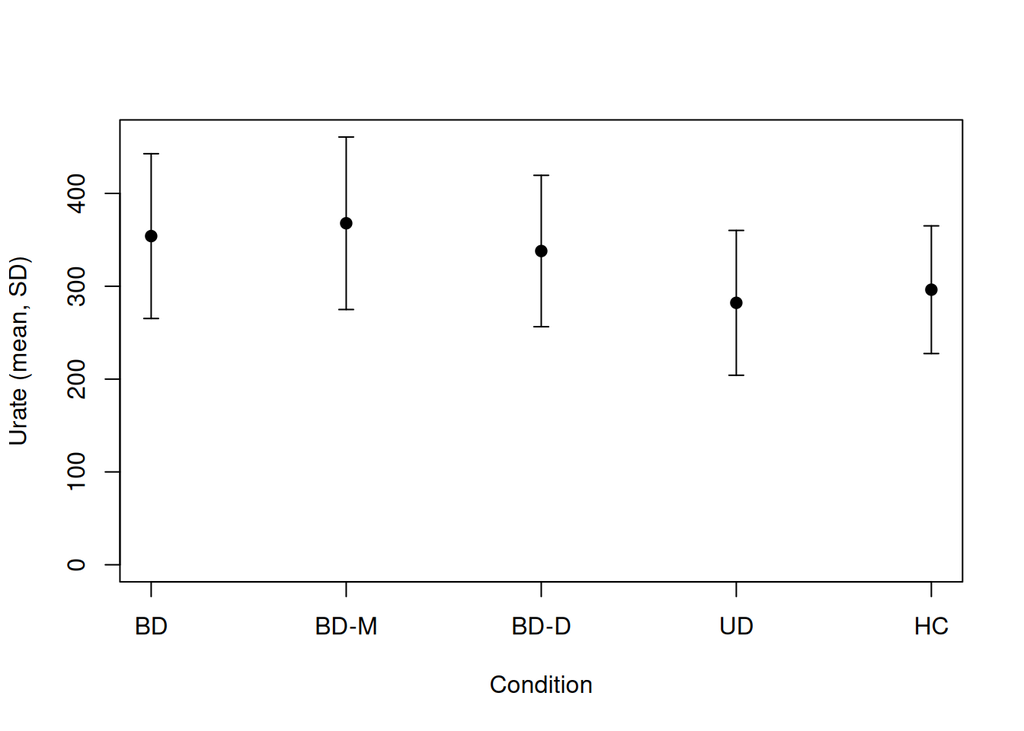

Allopurinol mot mani[106]

### 8.2.6 Screening för bipolärt syndrom vid misstanke

MDQ är en screeningsskala för bipolärt syndrom.

- Den innehåller 13 frågor som besvaras med antingen ja eller nej.
- Vid mer än 7 ja-svar är det 70% sannolikhet att patienten lider av en bipolär – och inte unipolär – depression.

MDQ är enkel och går snabbt att använda.

**Observera** att MDQ ger en statistisk sannolikhet, den ställer inte diagnos!

Höga poäng vanligt vid exempelvis emotionellt instabilt personlighetssyndrom [97].

### 8.2.7 Kartläggning av förlopp, symtom mm

Har betydelse för differentialdiagnostik, prognos, behandlingsval, utredning och behandling av samsjuklighet. Utförs gärna med livslinje, och med hjälp av anhöriga eller arbetskamrat.

- Duration av aktuell och tidigare episoder
- Svårighetsgrad av aktuell och tidigare episoder
- Ärftlighet inklusive anhörigas respons på viss behandling
- Förlopp
  - Debutålder (första episod mani eller depression?)
  - Antal och frekvens av tidigare episoder
  - Säsongsvariation
  - Post-partumbesvär
  - Premenstruella besvär
  - Ljus och temperatur kan påverka förlopp och uttryck
- Episodkarakteristika
  - Symtomvariation under dagen
  - Sömnbesvär, sömntid, dagtrötthet
  - Depressiva symtom vid mani (blandade drag?)
  - Maniska symtom vid depression (blandade drag?)
  - Ångest (“with axious distress” ?)
  - Psykotiska symtom (stämningskongruenta eller icke-)
- Prodromalsymtom/tidiga varningstecken (kognitiva besvär, sömn, diskreta psykomotoriska förändringar)
- Utlösande faktorer
  - Nyinsatta läkemedel (kan vara utlösande faktorer)
  - Thyroideastatus (subklinisk hypothyreos kan utlösa skov)
  - Förvärring av affektiva symtom vid antidepressiv behandling
  - Livshändelser. Yttre stress kan utlösa episoder tidigt i förloppet, men senare tycks episoderna komma utan sådana faktorer.
- Samsjuklighet
  - Drog och alkoholbruk
  - Thyroideasjukdom
  - Ångestsyndrom
- Tidigare behandlingar (duration, dos, effekt, biverkningar)
- Tidigare skalltrauma
- Följsamhet till behandling: Har skovet att göra med att pågående behandling avslutats?
- Suicidrisk
- Bedöm förutsättningarna för följsamhet till behandlingsplan
- Psykosocialt nätverk: Betydelse för bla avgörande om inneliggande eller poliklinisk behandling, behov av tät uppföljning
- Funktionsnedsättning: Stor funktionsnedsättning kan föranleda mer aktiv behandling, evtuell sjukhusvård
- Provtagning [97]
  - EKG (QTT)
  - Thyroideastatus
  - BMI
  - Blodstatus
  - Glukos
  - Leverstatus
  - Elektrolytstatus inkl kalcium (hyperparathyroidism vid litiumbehandling)
  - Urinsticka
  - Urin-drogscreening
  - Prolaktin (för uppföljning av antipsykotiska medel)

### 8.2.8 Samsjuklighet

Samsjuklighet/riskbeteenden.

Identifiera komorbiditet: Substansbruk, obesitas, thyroideasjukdom, ångesttillstånd, ätstörning, migrän.

Metabola syndromet vanligt vid BP (prevalens 20-65%). Inbegruper bukfetma, hypertoni, glukosintolerans, diabetes mellitus, dyslipidemi. Är förknippat med sämre prognos avseende bipolära symtom.

Psykiatrisk samsjuklighet är vanligt, ffa ångestsyndrom (hos ca 75%), ADHD, uppförandestörning, substansbrukssyndrom (50% av BPI).

### 8.2.9 Differentialdiagnostik vid mani

#### 8.2.9.1 Uteslut bakomliggande medicinsk åkomma

Överväg särskilt vid debut av mani sent i livet. Se Larsson 1988[108].

- Demens
- Delirium
- Läkemedel
  - Tex kortikosteroider, levodopa, thyroxin
- Hjärntumör
  - Frontalt, diencefalon, hypothalamus
- Epilepsi
  - Temporallob
- Stroke
  - Temporallob, hemisfärisk
- Huntingtons sjukdom
- Encefalit
- Multipel skleros
- SLE
- Cushing och Addison
- Läkemedel
  - Drogbruk
  - Antidepressiva
  - Kortikosteroider
  - Androgener
  - Elektrokonvulsiv behandling
  - Isoniazid (TB-behandling)
  - Klorokin (malaria/reumabeh)
  - Subklinisk hypothyreos
- mm

### 8.2.10 Differentiera mot andra psykiatriska tillstånd

#### 8.2.10.1 EIPS

- Instabila relationer
- Växlande självbild
- Uttalad impulsivitet
- Rädsla för att bli övergiven
- Humörsvängningar utlöses av omgivningsfaktorer och varar minuter-timmar
- Eufori och långvariga perioder med god funktion är mycket ovanligt
- Kan bättras över livstiden
- Ej episodisk
- Motorisk acceleration talar för mani

Vid narcissistiskt personlighetssyndrom kan grandiositet föreligga, men är ej förknippat med humörförändringar eller funktionsnedsättning[97].

#### 8.2.10.2 Differentiera manisk psykos vs schizofreni

Psykotiska symtom utan framträdande affaktiva sytom talar för schizofreni, schizoaffektivt syndrom, eller vanföreställningssynrom.

Förekomst av tankestörning är lika vanligt vid mani och schizofreni. Vid mani är det möjligen vanligare med talträngdhet, pressat tal, grandiositet, kombinatoriskt och överinklusivt tänkande, tankeflykt, tangentialitet, derailment och loss of goal. Vid schizofreni är tankefattighet, minskad talproduktion, och lägre komplexitet i talet vanligare. Skillnaderna kan konceptualiseras som att man vid schizofreni ser mer oordnat innehåll emedan det vid mani är mer tankestrukturen som är störd. Vid mani kan mer lekfullhet och humor noteras i talet. Vid mani kan temat för det personen säger skifta, emedan personer med schizofreni kan ha svårigheter att elaborera överhuvud taget. Tankestörning vid bipolärt syndrom kan kvarstå i remission. [95]

#### 8.2.10.3 ADHD

Symtom vid bipolärt syndrom och ADHD överlappar till hög grad (tex rusande tankar, snabbt tal, distraherbarhet, minskat sömnbehov). Upp till 20% av personer med BP uppfyller kriterier för ADHD och tvärtom [97]. För att särskilja dessa bör symtomens episodiska karaktär vid BP klarläggas.

### 8.2.11 Psykos vid bipolärt syndrom

Ungefär en tredjedel av personer med bipolärt syndrom har någon gång upplevt ett eller flera psykotiska symtom [95], och detta kan vara vanligare vid tidig debut. Om ärftlighet finns för mani eller är risken för psykos större. Vid schizofreni är vanföreställningarna ofta desamma över lång tid, emedan de vid mani (och bipolär depression) är mer skiftande, och kan komma och gå under en dag. Vid mani är vanföreställningarna ofta kopplade till patientens grandiositet. Religiösa vanföreställningar är vanligast, följt av politiska (framför allt hos män) och sexuella teman. En femtedel av personer med bipolärt syndrom har upplevt hallucinationer under depression eller mani och de är vanligen hörselhallucinationer tematiskt kopplade till det stämningsläge och de vanföreställninger personen har. Vanligen inser personen att andra inte upplever dessa hallucinationer samtidigt. Anklagande röster är mer vanligt vid schizofreni.

Tidig debut med psykotisk depression är kopplat till ökad risk för senare manisk episod. Stämningsinkongruenta psykotiska symtom är förknippat med sämre prognos, kan vara mer likt schizofreni [95]?

Olika vanligt/olika typer av psykotiska symtom vid depressiv vs manisk episod och BPI vs BPII.

## 8.3 Behandling

Överväg differentialdiagnoser som drogutlöst psykos, andra organiska psykoser, demens, eller schizoaffektivt syndrom. Se avsnitt om somatiska orsaker till mani 8.2.9.1 och avsnitt 8.2.10 om psykiatriska differentialdiagnoser.

Olika faser av behandling kan konceptualiseras enligt följande [95, kap 17]:

**Akut behandling:** Från episodens början fram till klinisk respons eller remisson. Vanligen 6-12 veckor efter episodens debut. Indelas i akut behandling av hypomani/mani respektive akut behandling av bipolär depression samt akut behandling av blandad episod.

**Fortsättningsbehandling:** Från respons fram till den tidpunkt då spontan förbättring skulle ha förväntats utan behandling. Vid bipolär depression ca 6 månader, vid mani 4 månader (dock kan post-manisk depression inträffa).

**Underhållsbehandling:** Syftar till att minska antal och svårighetsgrad av nya episoder. Överlappar med både fortsättningsbehandling och profylax.

Goodwin påpekar att många studier av “underhållsbehandling” endast täcker en relativt kort period efter ett bipolärt skov och att de därför kanske inte är tillämpbara för långtidsbehandling under flera år. Ofta används dock endast akut fas (mani eller depression) respektive underhållsbehandling (profylax, prevention) som definitioner.

### 8.3.1 Behandling enligt olika riktlinjer

Olika internationella riktlinjer ger liknande rekommendationer som kan sammanfattas enligt följande[109]. Se även kommentar på CANMAT 2018[110].

Tre typer av läkemedel är grunden i behandlingen:

1. Litium
2. Valproat
3. Antipsykotiska medel: Kvetiapin eller olanzapin

**Monoterapi:** Litium, valproat, kvetiapin, och olanzapin har gott stöd för effekt i alla faser (mani, depression, proyfylax). Valproat kan vara något sämre som profylax mot mani än de andra.

**Kombinationsbehandling:** Kombinationsbehandling anses mer effektivt än monoterapi (ca 20% fler svarar på behandlingen)[97]. Kvetiapin tillsammans med litium eller valproat har effekt i alla faser, men är kanske mindre effektivt vid akut depression. Andra kombinationer används också, men har svagare vetenskapligt stöd.

**Lamotrigin** i monoterapi har preventiv effekt mot depressioner och kanske viss effekt vid pågående depression. Det rekommenderas som kombinationsbehandling i en del riktlinjer, trots bristande underlag.

Tabell: Huvudsakliga behandlingsalternativ i olika faser av bipolärt syndrom typ 1.

| Behandling | Mani | Depr | Prof | Prof mani | Prof depr | Notering |
| --- | --- | --- | --- | --- | --- | --- |
| Litium | Ja | Ja | Ja | Ja | Ja | Troligen bäst |
| Valproat | Ja | (Ja) | Ja | (Ja) | Ja | Vid alkoholism |
| Karbamazepin | Ja | (Ja) | Ja | Ja | Ja | Interaktioner |
| Lamotrigin | Nej | (Ja) | Ja | Nej | Ja | Få biverkningar |
| Kvetiapin | Ja | Ja | Ja | Ja | Ja | Metabola biv |
| Olanzapin | Ja | Ja | Ja | Ja | Ja | Metabola biv |
| Aripiprazol | Ja | Nej | Ja | Ja | ? | Akatisi |
| Li/va + Kvet | Ja | (Ja) | Ja | Ja | Ja |  |
| Li/va + Ozp | Ja | ? | (nja) | (nja) | (nja) |  |
| Li/va + Apz | Ja | (nja) | Ja | Ja | ? |  |

Vid akut depression har kariprazin (monoterapi) och lurasidon (monoterapi eller med li/valproat) visad effekt. Aripiprazol (och en rad andra antipsykotiska medel) har effekt vid akut mani.

Att överväga:

- Vid svår mani bör kombinationsbehandling övervägas tidigt.
- Vid psykos bör antipsykotiskt medel troligen ingå.
- Vid svår depression eller vid mani som ej svarar på farmakologisk behandling överväg ECT.
- Vid akut depression är det mindre vanligt att kombinationen litium + valproat rekommenderas. Istället rekommenderas ibland att kombinera med lamotrigin (upp till trippelbehandling Li/val + AP + LTG), trots svagt vetenskapligt stöd.
- Vid depression kan antidepressiva läggas till i andra hand och i så fall tillsammans med li/val/ap. I tredje hand kan tex thyroideahormon, eller rTMS övervägas.
- Vid blandad episod eller rapid cycling är evidensläget osäkert. Kan behandlas som mani men i första hand välja preparat som även används vid depression?

#### 8.3.1.1 Kan provas enligt någon riktlinje

Annat att prova vid mani: Karbamazepin, Klozapin, Allopurinol, Li/Val + medroxyprogesterone, Val + celcoxib, rTMS, Tamoxifen

Annat att prova vid akut depression: Li/val + (or modafinil or pramipexole), Li + pioglitazone, CLZ, Add buspirone or stimulant or thyroid hormone, ECT, rTMS, modafinil, eicosapentaenoic acid, rTMS, ketamine, light therapy/sleep deprivation, Levothyroxine, N-acetylcysteine, pramipexole, ARP, armodafinil

### 8.3.2 Behandling tumregler

1. Litium (särskilt vid klassisk euforisk mani, få tidigare episoder, när manier har följts av depression, och vid hereditet för bipolärt syndrom, särskilt om släktingen svarat på litium)
2. Valproat (ej till fertila kvinnor, kan föredras vid alkoholberoende)
3. Antipsykotiska medel med effekt i alla faser (kvetiapin, olanzapin)
4. Lamotrigin (främst evidens för prevention depression)
5. Antidepressiva: Endast under depressiv episod
1. Överväg litium. Har effekt i alla faser.
2. Om litium är olämpligt kan valproat vara ett alternativ.
3. Om snabb effekt behövs, lägg till ett AP med effekt i alla faser (kvetiapin, olanzapin, alt kanske aripiprazol)
4. I andra hand: Trippelkombination, tillägg AD tillfälligt, ECT, rTMS, lamotrigin (mot depression)

Aripiprazol ej ångestdämpande. Kombineras därför gärna med benso.

#### 8.3.2.1 Resonemang akut mani

Metabola biverkningar ett mindre problem (om behandlingstid <4-6 veckor). Sedering och ångestdämpning kan vara en fördel.

Tidigare obehandlad patient: Sikta på snabb insättning av litium med tillägg av kvetiapin vid psykos, svår mani, ångest, eller sömnsvårigheter. Trappa ut kvetiapin när målkonc litium uppnåtts. Blir biverkningarna av litium intolerabla kan man istället behålla kvetiapin.

Ordination:

- Litium: 3+3 i 2d => 2+3 i 2d => 2+2. Serumkonc dag 2-3 för vägledning.
  - Målkonc 0.9 (0.8-1.2).
  - Tänk på att mani konsumerar litium, så sänkning behövs efteråt.
- Kvetiapin: Depot 300 mg tn, dag 2 ges 600 mg. Kan ökas till 800 mg.
- Zopiklon: 7.5 mg tn vb.
- Agitation/ångest: Lorazepam 1-2 mg (po eller im) vb varannan timme.
- Utebliven effekt efter 1-2 veckor: Halvera litium och ge ECT?

### 8.3.3 Val av behandling enligt CANMAT 2018

Canadian Network for Mood and Anxiety Treatments (CANMAT) har publicerat omfattande riktlinjer för behandling av bipolärt syndrom [97].

**Tabell 8.3** visar behandlingsalternativ i olika faser vid bipolär sjukdom med första- och andrahandsalternativ vid mani [97]. **Tabell 8.4** första- och andrahandsalternativ vid akut bipolär depression [97]. **Tabell 8.5** första- och andrahandsalternativ vid underhållsbehandling av bipolärt syndrom [97].

Vissa behandlingar med god evidens (tex olanzapin) nedgraderas till andrahandsval på grund av sämre tolerabilitet eller större biverkningsproblem.

Tabellerna är hierarkiskt ordnade så att de läkemedel som står högre upp bör provas först. Alla förstahandsval bör prövas innan andrahandsval används. Särskilda skäl kan finnas att frångå hierarkin, såsom blandad episod, tidigare icke-respons till litium, och samsjuklighet med substansbrukssyndrom [97].

Överväg om ett preparat som lämpar sig för underhållsbehandling kan användas även i den akuta fasen. Ett hinder kan dock vara svårighet att diskutera behandlingsalternativen med patienten.

### 8.3.4 Behandling av manisk episod

Med litium eller valproat uppnår ca 50% respons (minst 50% reduktion av YMRS) efter tre veckor, jämfört med 25% för placebo. Tillägg av olanzapin/risperidon/kvetiapin (troligen samma för andra antipsykotiska medel) till litium eller valproat är bättre än placebo hos dem med ingen eller partiell respons[95].

- Avsluta pågående antidepressiva läkemdel.
- Tillse god sömn med hypnotiska medel eller bensodiazepiner.
- Risk för dehydrering föreligger. Även risk för rhabdomyolys. Tillgodose vätskeintag.
- Om patienten redan har stämningstabiliserande behandling (litium, valproat, lamotrigin) optimera dosen av befintlig stämningsstabiliserare.
- Välj behandling enligt tabellerna nedan.
- Vid utebliven respons efter 4-14 dagar, överväg kombinationsbehandling.

CANMAT noterar att alla antimaniska läkemedel separerar från placebo inom en vecka, varför utebliven respons efter två veckor (och bidragande faktorer har uteslutits) bör byte- eller tillägg av behandling övervägas [97]. Goodwin rekommenderar att man redan vid utebliven respons efter 4-5 dagar överväger kombinationsbehandling.

I återhämtningsfasen av mani är det vanligt med svängningar i stämningsläge och beteende, varför läkemedel med effekt mot depression, eller kombinationsbehandling, kan vara lämpligt. Snabbt insättande av behandling kan motiveras av att maniska perioder kan påverka hjärnan [111].

Kombinationsbehandling är mer effektivt än monoterapi (ca 20% fler svarar på behandlingen)[97]. Särskilt vid behov av snabb respons (uttalad mani, suicidrisk) kan kombinationsbehandling vara att föredra. Likaså om tidigare partiell respons (akut eller i i underhållsfas) på monoterapi. Väg in patientens villighet att ta kombinationsbehandling.

#### 8.3.4.1 Faktorer som kan påverka val av behandling av maniskt skov

**Tidigare respons på visst läkemedel**: Litium är mer effektivt än valproat hos de som tidigare haft effekt av litium, och tvärtom [95].

**Extrem hyperaktivitet:** Antipsykotiska läkemedel ger snabbast effekt.

**Agitation:** Förstahandsval är ariprazol (10 mg im, max 15 mg/d), lorazepam (2 mg im), olanzapin (2.5 mg im, max 10 mg/d) [97]. Intramuskulärt olanzapin har bättre effekt än im lorazepam vid manisk agitation [95, kap 17].

**Psykotiska symtom:** Det finns inget vetenskapligt stöd för att antipsykotiska medel i monoterapi eller som del av kombinationsbehandling är mer effektivt än andra alternativ, men klinisk erfarenhet indikerar att ett atypiskt antipsykotiskt medel bör ingå i behandlingen vid stämningsinkongruenta psykotiska symtom (dvs annat än grandiosa vanföreställningar). Likaså när schizoaffektivt syndrom kan misstänkas. [97]

**Blandad episod:** Valproat i monoterapi kan möjligen vara mer effektivt än litium i monoterapi, men den studie som visat det begränsas av att många av patienterna ej svarat på litium vid tidigare behandling. För patienter som stabilserats med en kombination av litium och valproat har dessa läkemedel i monoterapi likvärdig (begränsad) effekt som underhållsbehandling [95, kap 17]. Valproat eller atypiska antipsykotiska har vetenskapligt stöd och ofta behövs kombinationsbehandling [97]. De med blandad episod/höga poäng på depressionsskattning, eller mer än tio tidigare affektiva episoder kan ha bättre effekt av valproat än litium [95].

**Rapid cycling:** Valproat i monoterapi kan möjligen vara mer effektivt än litium i monoterapi, men den studie som visat det begränsas av att många av patienterna ej svarat på litium vid tidigare behandling. Olanzapin har likvärdig effekt vid rapid cycling och icke-rapid cycling [95, kap 17]. Hypothyroidism, substansbruk, och antidepressiva är associerade med rapid cycling och bör adresseras [97]. Relativ effekt av viss behandling har ej studerats. Val av behandling bör göras utifrån effekt i underhållsfasen, ofta behövs kombinationsbehandling [97].

- Avsluta eventuella antidepressiva. Även kombinationen AD + stämningsstabiliserare bör undvikas.
- Lithium, valproat, olanzapine, och kvetiapin har liknande effekt i underhållsfas vid rapid cycling emedan lamotrigin ej skiljer sig från placebo.
- Särskilt viktigt att undvika drog/alkoholbruk

**“Klassisk” mani** (eufori, grandiositet, frånvaro av depressiva symtom, utan rapid cycling): Litium kan vara mer effektivt än valproat [95, kap 17,97].

**Anxious distress**: Vanligt och förutsäger sämre prognos (svårare maniska symtom, längre tid till remission). Valproat, kvetiapin, och olanzapine kan vara fördelaktigt pga anxiolytisk effekt, liksom karbamazepin [97].

**Behov av snabb respons:** Kombinera litium eller valproat med atypiskt antipsykotiskt medel [97].

**Biverkningsprofil:** De biverkningar som är mest oroande för patienter är viktuppgång, kognitiv påverkan och sedering [95, kap 17].

Tabell 8.3: Förstahandsbehandling vid bipolär sjukdom i manisk fas

| Läkemedel | Mani | Depression | Prevention båda | Prevention mani | Prevention depression | Särskilt vid |
| --- | --- | --- | --- | --- | --- | --- |
| Litium | ++++ | +++ | ++++ | ++++ | ++++ |  |
| Kvetiapin | ++++ | ++++ | ++++ | ++++ | ++++ | + Ångest, blandad episod, inkongruenta vanföreställningar |
| Valproat | ++++ | +++ | ++++ | ++ | +++ | + Multipla episoder, irritabilitet, dysfori, ångest, substansbrukssyndrom, skalltrauma, EJ till fertil kvinna |
| Asenapin | ++++ | nd | +++ | +++ | +++ |  |
| Aripiprazol | ++++ | ---- | +++ | +++ | nd | + Ångest, blandad episod, inkongruenta vanföreställningar |
| Paliperidon | ++++ | ---- | +++ | +++ | nd |  |
| Risperidon | ++++ | nd | + | + | nd | + Ångest, inkongruenta vanföreställningar |
| Kariprazin | ++++ | ++++ | nd | nd | nd |  |
| Kvetiapin + li/va | ++++ | + | ++++ | ++++ | ++++ | + Svår mani |
| Aripiprazol + li/va | +++ | + | +++ | +++ | nd | + Svår mani |
| Risperidon + li/va | ++++ | + | + | + | nd | + Svår mani |
| Asenapin + li/va | +++ | + | + | + | nd | + Svår mani |

**Note:** <sup>a</sup>Tabellen visar förstahandsalternativ för behandling av mani enligt CANMATs riktlinjer 2018. Kolumnerna mani respektive depression avser behandling av akuta episoder. Förkortningar: nd, No data; li, litium; va, valproat.

Tabell 8.3: Andrahandsbehandling vid bipolär sjukdom i manisk fas

| Läkemedel | Mani | Depression | Prevention båda | Prevention mani | Prevention depression | Särskilt vid |
| --- | --- | --- | --- | --- | --- | --- |
| Olanzapin | ++++ | ++++ | ++++ | ++++ | ++++ | + Ångest |
| Karbamazepin | ++++ | ++ | +++ | +++ | +++ | + Skalltrauma, hög ångest, substansbruk, schizoaffektiv, inkonmgruenta vanföreställningar |
| Olanzapin + li/va | ++++ | nd | + | + | + |  |
| Litium + va | ++ | nd | ++ | ++ | nd |  |
| Ziprasidon | ++++ | ---- | + | + | nd |  |
| Haloperidol | ++++ | nd | nd | + | - |  |
| Ect | ++ | + | + | + | + |  |

**Note:** <sup>a</sup>Tabellen visar andrahandsalternativ för behandling av mani enligt CANMATs riktlinjer 2018. Kolumnerna mani respektive depression avser behandling av akuta episoder. Förkortningar: nd, No data; li, litium; va, valproat.

### 8.3.5 Behandling av bipolär depression

Sparsamt beforskat. Kvetiapin eller kombinationen olanzapin/fluoxetin har FDA-godkännande.

Patienter med bipolär depression svarar långsammare på behandling än de med mani. Residualsymtom är vanligt och bör behandlas.

- Regelbunden fysisk konditionsträning är fördelaktig vid depression.
- Behandla sömsvårigheter, ångest och agitation.
- Rekommendera patienten att begränsa nikotin, koffein och alkohol, samt förstås avstå drogbruk.
- Erbjud psykosociala insatser och psykoedukation för att förbättra följsamhet, minska residualsymtom, identifiera återfall, återfå funktionsförmåga och minska suicidalt beteende.

Om patienten står på litium, överväg öka litiumkoncentrationen till >0.8.

Kvetiapin + litium har ej studerats avseende effekt vid bipolär depression, men kan övervägas när något av dessa läkemedel redan används.

Tidig förbättring (inom 2v) är en hygglig prediktor för respons, emedan utebliven förbättring är en mer robust prediktor för icke-respons. Detta kan beaktas vid byte av behandling. Undantaget är lamotrigin, som kräver långsam titrering. [97]

För en läsvärd diskussion om behandling vid BP depression se [112].

#### 8.3.5.1 Faktorer som kan påverka val av behandling av depressivt skov

**Behov av snabb respons**: Pga svår depression, suicidalitet, dehydrering.

**Nedsatt kognition och psykomotorisk hämning:**

- Viss evidens att lamotrigin kan ha ökad effektivitet.

**Tidigare respons på visst läkemedel**: Tidigare respons på antidepressiva kan föranleda att sådana övervägs i kombination med antimaniskt läkemedel.

**Hög ångestnivå:** “Anxious distress”. Förutsäger mer ihållande depression samt mer suicidtankar.

- Kvetiapin samt olanzapin-fluoxetin mer effektivt än placebo [97].
- Anxiolytisk effekt av valproat, risperidon, och lamotrigin är begränsad [97].

**Blandad episod:** Associerat till svårare depressiva symtom, ökad förekomst av substansbrukssyndrom, och kardiovaskulär sjukdom. Ofta behövs kombinationsbehandling. Atypiska antipsykotiska medel har visat en klass-effekt vid blandad episod.

- Olanzapin + fluoxetin, asenapin, och lurasidon har visad effekt.
- Undvik antidepressiva

**Melankoliska drag:** Relativ effekt av viss behandling har ej studerats. Klinsikerfarenhet talar för att ECT är effektivt [97].

**Psykotiska symtom:** Både stämningskongruenta- och inkongruenta. Relativ effekt av viss behandling har ej studerats. Klinsikerfarenhet talar för att ECT samt antipsykotiska medel är effektivt [97].

**Rapid cycling:** Glöm ej undersöka thyroideastatus. Relativ effekt av viss behandling har ej studerats. val av behandling kan styras av behov i underhållsfasen.

- Avsluta eventuella antidepressiva. Även kombinationen AD + stämningsstabiliserare bör undvikas.
- Lithium, valproat, olanzapine, och kvetiapin har liknande effekt i underhållsfas vid rapid cycling emedan lamotrigin ej skiljer sig från placebo.
- Särskilt viktigt att undvika drog/alkoholbruk

#### 8.3.5.2 Antidepressiva läkemedel vid bipolärt syndrom

Antidepressiva bör i allmänhet undvikas [97] (särskilt vid anamnes på blandade episoder, rapid cycling, eller förstås hypomani/mani som utlösts av antidepressiva). Pågående andidepressiv behandling bör trappas ut (om inte flera utsättningsförsök redan misslyckats) [95, kap 17], särskilt vid mani/hypomani eller om depression uppträder trots pågående antidepressiv behandling [97]. Uttrappning eller byte av AD bör göras gradvis. Om antidepressiva används bör de kombineras med en “stämningsstabiliserare”. Antidepressiva som monoterapi bör EJ användas vid bipolär depression [97].

- Effektiviteten av AD ej etablerad för BP depression
- Utlösande av maniskt skov av AD har demonstrerats i studier
- Rekommenderas ej som monoterapi vid BP I
- Otillräckliga data för rekommendation vid BP II
  - Undvik vid blandad episod [97]
- Bör endast övervägas vid svår depression eller då annan behandling har misslyckats
  - Då alltid i kombination med stämningsstabiliserare
  - Bör sättas ut gradvis efter depressionsepisoden
    - Fortsättningsbehandling endast för dem med tidig relaps

#### 8.3.5.3 Augmentation med thyroideahormon?

- Kan vara av värde (även vid normala thyrodieaprover) hos…
  - Kvinnor
  - Rapid cycling
  - TSH > 50:e percentilen av normalvärde
- Använd T3 och gå med tiden över till T4

> First‐line options for bipolar I depression include quetiapine, lurasidone plus lithium or divalproex, lithium, lamotrigine, lurasidone, or adjunctive lamotrigine. While medications that have been shown to be effective for the acute phase should generally be continued for the maintenance phase in bipolar I disorder, there are some exceptions (such as with antidepressants); and available data suggest that lithium, quetiapine, divalproex, lamotrigine, asenapine, and aripiprazole monotherapy or combination treatments should be considered first‐line for those initiating or switching treatment during the maintenance phase. [97]

ECT bör övervägas hos bahandlingsrefraktära patienter och när snabb respons är viktigt (svår depresssion, hög suicidrisk, katatoni, psykotisk depression).

Ketamin har visat god och snabb effekt vid BP depression, men studierna är små. Kan övervägas vid behov av snabb respons.

Tabell 8.4: Förstahandsbehandling vid bipolär sjukdom i depressiv fas

| Läkemedel | Mani | Depression | Prevention båda | Prevention mani | Prevention depression | Särskilt vid |
| --- | --- | --- | --- | --- | --- | --- |
| Kvetiapin | ++++ | ++++ | ++++ | ++++ | ++++ | + behov av snabb respons, ångest, blandad episod |
| Lurasidon + li/va | nd | ++++ | ++ | + | ++ |  |
| Litium | ++++ | +++ | ++++ | ++++ | ++++ |  |
| Lamotrigin | ---- | +++ | ++++ | +++ | ++++ | + psykomotorisk hämning |
| Lurasidon | nd | +++ | + | + | + | + behov av snabb respons |
| Lamotrigin (adj) | - | +++ | + | + | + |  |

**Note:** <sup>a</sup>Tabellen visar förstahandsalternativ för behandling av depression enligt CANMATs riktlinjer 2018. Kolumnerna mani respektive depression avser behandling av akuta episoder. Förkortningar: nd, No data; li, litium; va, valproat.

Tabell 8.4: Andrahandsbehandling vid bipolär sjukdom i depressiv fas

| Läkemedel | Mani | Depression | Prevention båda | Prevention mani | Prevention depression | Särskilt vid |
| --- | --- | --- | --- | --- | --- | --- |
| Valproat | ++++ | +++ | ++++ | ++ | +++ |  |
| Bupropion/ssri (adj) | nd | + | nd | nd | + | + behov av snabb respons, ångest |
| Kariprazin | ++++ | ++++ | nd | nd | nd |  |
| Ect | ++ | + | + | + | + | + behov av snabb respons, psykotiska symtom |
| Olanzapin + fluoxetin | nd | +++ | nd | nd | nd | + ångest, blandad episod |

**Note:** <sup>a</sup>Tabellen visar andrahandsalternativ för behandling av depression enligt CANMATs riktlinjer 2018. Kolumnerna mani respektive depression avser behandling av akuta episoder. Förkortningar: nd, No data.

### 8.3.6 Underhållsbehandling

Riskfaktorer för återfall [97]:

- Yngre debutålder
- Psykotiska symtom
- Samsjuklighet med ångest
- Substansbrukssyndrom
- Resudualsymtom
- Bristande följsamhet

Dessa bör föranleda optimering av behandlingen.

Upp till 50% av patienter tar ej läkemedlen som de förskrivits. Detta kan leda till onödiga dosökningar, byten, eller tilläggsbehanlingar. Upphörande av behandling kan orsaka återfall (tex 50%-90% inom 3-5 månader för litium, större risk med abrupt avslut, även för andra stämninigsstabiliserare). Bristande följsamhet ökar även risk för nedsatt funktionsförmåga, hospitalisering och suicid. Interventioner för att öka följsamhet (tex psykoedukation) kan mer än fördubbla följsamheten [97].

Tillägga av psykosocial behandling till läkemedel reducerar återfall med ca 15% [97].

Faktorer associerade med lägre följsamhet [97]:

- Sociodemografiska: Manligt kön, yngre ålder, låg utbildningsgrad, ensamstående
- Psykologiska: Bristande insikt, bristande medvetenhet om sjukdom, negativ attityd till behandling, rädsla för biverkningar, missnöje med livet, låg kognitiv funktion
- Komorbiditet: Alkohol- eller cannabisbruk, OCD.
- Sociala: Inga sociala aktiviteter, jobbsvårigheter.
- Kronologi: Yngre debutålder, inneliggande vård, hospitalisering eller suicidförsök de senaste 12 månaderna.
- Sjukdomskarakteristika: Blandad episod, rapid cycling, vanföreställningar och hallucinationer, högre svårighetsgrad, BDI-diagnos, fler episoder.
- Behandingsrelaterade faktorer: Biverkningar, bristande effekt, användning av antidepressiva, låga doser.

Atypiska antipsykotiska är profylaktiska mot maniska episoder men profylaktiska effekt mot depressioner är osäker. När kombination av ett antipsykotiskt medel med litium eller valproat vid akut mani förebygger fortsättningsbahandling med antipsykotiskt medel relaps under sex månader, men fortsatt behanling därefter har osäker effekt. Därför bör behandling med antipsykotska medel omvärderas efter sex månader med tanke på biverkningsrisk och osäker effekt [97].

> If therapy with one or a combination of the first-line agents at optimal doses is inadequate or not tolerated, the next step is to switch to or add on an alternate first-line agent [97].

Tabell 8.5: Förstahandsbehandling vid bipolär sjukdom i underhålls fas

| Läkemedel | Mani | Depression | Prevention båda | Prevention mani | Prevention depression | Särskilt vid |
| --- | --- | --- | --- | --- | --- | --- |
| Litium | ++++ | +++ | ++++ | ++++ | ++++ | + hereditet, ej ångest/substansbrukssyndrom, typiska symtom, mani-depression-eutymi |
| Kvetiapin | ++++ | ++++ | ++++ | ++++ | ++++ | + blandade episoder, ångestsyndrom |
| Valproat | ++++ | +++ | ++++ | ++ | +++ |  |
| Lamotrigin | ---- | +++ | ++++ | +++ | ++++ | - frekventa manier |
| Asenapin | ++++ | nd | +++ | +++ | +++ |  |
| Kvetiapin + li/va | ++++ | + | ++++ | ++++ | ++++ | + Ångestsyndrom |
| Aripiprazol + li/va | +++ | + | +++ | +++ | nd |  |
| Aripiprazol | ++++ | ---- | +++ | +++ | nd |  |

**Note:** <sup>a</sup>Tabellen visar förstahandsalternativ för behandling i underhållsfas enligt CANMATs riktlinjer 2018. Kolumnerna mani respektive depression avser behandling av akuta episoder. Förkortningar: nd, No data; li, litium; va, valproat.

Tabell 8.5: Andrahandsbehandling vid bipolär sjukdom i underhålls fas

| Läkemedel | Mani | Depression | Prevention båda | Prevention mani | Prevention depression | Särskilt vid |
| --- | --- | --- | --- | --- | --- | --- |
| Olanzapin | ++++ | ++++ | ++++ | ++++ | ++++ |  |
| Risperidon lai | nd | nd | ++++ | ++++ | nd |  |
| Risperidon lai (adj) | nd | nd | +++ | +++ | + |  |
| Kariprazin | ++++ | ++++ | nd | nd | nd |  |
| Paliperidon | ++++ | ---- | +++ | +++ | nd |  |
| Ziprasidon + li/va | --- | -- | +++ | +++ | nd |  |
| Lurasidon + li/va | nd | ++++ | ++ | + | ++ |  |

**Note:** <sup>a</sup>Tabellen visar andrahandsalternativ för behandling depression enligt CANMATs riktlinjer 2018. Kolumnerna mani respektive depression avser behandling av akuta episoder. Förkortningar: nd, No data; li, litium; va, valproat.

### 8.3.7 Läkemedel vid bipolärt syndrom

Tidigare respons på litium förutsäger bättre respons under aktuell manisk episod, och sämre effekt av antiepileptiska läkemedel. Nivåer över 0.8 mmol/L mer effektiva vid mani än lägre nivåer [95].

Litium föredras framför valproat vid klassisk euforisk mani, få tidigare episoder, när manier har följts av depression, och vid hereditet för bipolärt syndrom (särskilt om släktingen svarat på litium) [97].

> Patients who respond well to lithium treatment usually have an episodic remitting pre-treatment clinical course, a family history of BD (especially BD responsive to lithium), low rates of comorbidity (especially anxiety and substance abuse disorders), and a pattern of mania-depressioneuthymia in biphasic episodes, as well as a typical clinical presentation. Responsiveness may also be a familial trait, with a study showing that patients who have a lithiumresponsive relative have a 67% likelihood of also being lithium responsive, versus 35% of those without a responsive relative. [97]

Vid akut mani kan litium ges med bolusdos för snabb upptrappning, tex 3+3 tabl i 2d => 2+3 i 2d => 2+2 i 2d. Följ litiumkoncentrationen (orienterande prov efter två dagar). Obs att antimanisk effekt kräver högre målkoncentration. Kan sättas ut om pat ej vill fortsätta m litium.

Underhållsbehandling: Konsensus målkoncentration (dalvärde 12 tim +- 1 tim efter senaste dos, även vid singeldosering) 0.60-0.80 mmol/L. Kan reduceras till 0.40-0.60 mmol/L vid god effekt men dålig tolerans. Kan ökas till 0.80-1.00 mmol/L vid otillräcklig respons och god tolerans. Nivåer över 1-1.2 mmol/L (ingen konsensus) bör ej överskridas [113]. Nivåer > 0.8 mmol/L kan vara av värde för dem som främst har maniska episoder, men sannolikt ej för andra, och är förknippat med ökad risk för biverkningar, renal toxicitet, och minskad följsamhet [114].

Engångsdosering till kvällen kan eventuellt öka följsamhet, reducera polyuri och medföra mindre påverkan på njurarna, utan försämrad effektivitet [115,116].

**Valproat:** De vanligaste biverkningarna är illamåend och trötthet. Påverkar metabolismen av flera andra läkemedel, bla lamotrigin. Vid akut mani krävs plasmakoncentration >45 mkg/ml för effekt och biverkningar blir problematiska vid nivå >125 mkg/ml. Snabb upptrappning (30 mg/kg d 1-2, 20 mg/kg d 3-10) kan ge snabbare effekt vid akut mani, men är likvärdig med olanzapin.

Valproat är lika effektivt vid klassisk- och dysforisk mani. Rekommenderas för de som haft multipla tidigare episoder, framträdande irritabilitet, framträdande dysfori, samsjuklighet med substansbrukssyndrom, eller anamnes på trauma mot huvudet [97]. Undvik hos kvinnor i fertil ålder.

Dosering vid mani:

- Starta 750 mg/dag eller 20 mg/kg. Enterotabletten doseras tre gånger per dag. Depotberedning kan ges en eller två gånger per dag.
- Dosen bör höjas så snabbt som möjligt för att uppnå lägsta terapeutiska dos.
- Måldos vanligen 1000-2000 mg/d (40-60 mg/kg/d). Max 60 mg/kg/d.

Monitorering:

- Tre till fem dagar efter senaste dstitrering, 12 tim efter senaste dos
- Kontrollera x2 under akut fas
- Monitorera vid uppföljning varje 3-6 månader
- Visst stöd för bättre effekt av högre koncentrationer vid akut mani
- Målkoncentration 350700 mM/L (50100 ug/mL) i akut fas [97]
- Valproatnivå ≥110 mkg/mL hos kvinnor eller ≥135 mkg/mL hos män ökar risken för trombocytopeni.

> Den dagliga dosen ska fastställas och kontrolleras individuellt av den behandlande läkaren. Den rekommenderade initiala dagliga dosen är 750 mg. Dessutom har en startdos på 20 mg valproat per kg kroppsvikt i kliniska studier också visat sig ha en acceptabel säkerhetsprofil. Depotformuleringar kan ges en eller två gånger dagligen. Dosen bör höjas så snabbt som möjligt för att uppnå lägsta terapeutiska dos, som ger önskad klinisk effekt. Den dagliga dosen ska anpassas till det kliniska svaret för att fastställa lägsta effektiva dos för den individuella patienten. Den genomsnittliga dagliga dosen valproat ligger vanligen mellan 1000 mg och 2000 mg. Patienter som får högre dagliga doser än 45 mg/kg kroppsvikt bör följas noggrant. Fortsatt behandling av maniska episoder vid bipolär sjukdom ska anpassas individuellt och lägsta effektiva dos ska användas. [FASS]

> Behandling av maniska episoder, profylaktisk behandling av bipolär sjukdom (vuxna): Vid behandling av bipolär sjukdom är den rekommenderade underhållsdosen mellan 500 mg och 2000 mg dagligen fördelat på 1 eller 2 doser. I undantagsfall kan dosen höjas till högst 3000 mg dagligen. Den individuella dosen beror på den kliniska effekten, men plasmanivåer på 50-125 mg/l bör eftersträvas. Vid profylaktisk behandling ska lägsta möjliga dos ges [FASS].

Äldre: En lägre initial dos och långsam upptitrering rekommenderas.

**Karbamazepin**: Faktorer som kan vara förnippade med respons på karbamazepin är anamanes på skalltrauma, samsjuklighet med ångest och substansbrukssyndrom, schizoaffektiv bld med stämningsnkongruenta vanföreställningar, ingen bipolär sjukdom hos förstagradssläktingar [97].

- Monitorering av serumnivåer kan göras för att kontrollera följsamhet och undvika toxisk nivå.

**Lamotrigin:** Har FDA-indikation för behandling (prevention?) av bipolär depression. Preventivmedel kan minska lamotriginkoncentrationerna (men ej omvänt).

- Dosering BP depression: Viss antidepressiv effekt redan vid 50 mg [95]. CANMAT rekommenderar minst 200 mg/d [97]. Långsam titrering för att undvika hudbiverkningar. Allvarliga hudreaktioner är ovanligt.
- Trappas upp gradvis för att minska risken för hudutslag.
- I monoterapi och frånvaro av andra läkemedel som påverkar metabolismen av lamotrigin starta 25 mg/d i två veckor. Uptitrera gradvis till 200 mg enligt FASS.

Incidensen av allvarliga hudbiverkningar (toxisk epidermal nekrolys och Steven-Johnssons syndrom) är 0.3-1% och lägre (0.02%) vid långsam titrering [97].

Vid godartade hudutslag (uppträder hos 10%) kan läkemedlet stoppas för att sedan återintroduceras med lägre startdos (5-12.5 mg/d, alt 25 mg vad) och långsammare titrering. Godartade utslag karakteriseras av: Som värst inom några dagar och lägger sig efter 10-14 dagar; prickigt, icke-konfluerande, ej ömmande; frånvaro av systemiska symtom (tex feber, lymfadenopati, allmänpåverkan); involverar ej mukösa membran (mun, läppar, ögon), normala labbprover (blodstatus, leverstatus, kreatinin, urinsticka). Utslag som uppträder inom 5 dagar är troligen ej läkemedelsrelaterade [117].

**Olanzapin:** Olanzapin som tilläggsbehandling har visat likvärdig effekt vid akut mani respektive blandad episod.

- Dosering vid akut mani: 2.5-5 mg var 6:e tim, kan titreras till 20 mg/d (dock visar vissa studier att 2.5-5mg kan vara tillräckligt).

**Kvetiapin:**

- Tablett tas:
  - Mani: Doseras två gånger dagligen. Total dygnsdos under de fyra första terapidagarna är 100 mg (dag 1), 200 mg (dag 2), 300 mg (dag 3) och 400 mg (dag 4). Kan ökas med 200 mg till max 800 mg/d.
  - BP depression: Doseras en gång dagligen. Total dygnsdos för de fyra första dagarna är 50 mg (dag 1), 100 mg (dag 2), 200 mg (dag 3) och 300 mg (dag 4).
- Depottablett tas (minst 1 tim före måltid):
  - Mani: Startdosen är 300 mg dag 1 och 600 mg dag 2.
  - BP depression: Den totala dygnsdosen för de 4 första dagarna är 50 mg (dag 1), 100 mg (dag 2), 200 mg (dag 3) och 300 mg (dag 4). Måldos 300 mg. Doser över 300 mg ger ej bättre effekt. Lägre doser har ej studerats [97].

**Risperidon:**

- Dosering vid akut mani: 1 mg vaje 6-8 tim, maxdos vanligen 6-8 mg/d.

**Aripiprazol:** Samtidig behandling med bensodiazepin kan vara fördelaktigt för att undvika initial aktivering. Aripiprazol (15-30 mg) har visat bättre effekt än haloperidol (10-15 mg/d) i en stor RCT, troligen pga mindre biverkningar.

- Dosering vid akut mani: Starta med 30 mg/d. Sänk till 15 mg/d vid biverkningar.

**Lorazepam**:

- Dosering vid akut mani: 1-2 mg (im el po) varje 2 tim. Samma för klonazepam.

**ECT:**

Tillägg av antipsykotiskt läkemedel till ECT mer effektivt än tillägg av placebo.

**rTMS:**

Ej första- eller andrahandsval. Högersidig rTMS ger mer förbättring av mani än vänstersidig (som används vid depression)

### 8.3.8 Bipolär typ II - behandling

Vid bipolär II finns mycket sparsamt med vetenskapliga studier som kan guida behandling, varför man får extrapolera från studier om bipolär I och kanske unipolär depression. Likaså vid samsjuklighet med andra psykiatriska tillstånd och vid bipolär depression. Det samma gäller för hypomani, där man får extrapolera från behandling av mani. Det är tänkbart att reduktion av hypomanier kan minska efterföljande depressiva episoder.

> Clinical experience and the results of many studies suggest that response to mood stabilizers and antipsychotics is similar in BDII and BDI, there are enough exceptions to suggest this should not be taken for granted. This is also the case for antidepressants, which may have a more favourable risk‐benefit ratio in BDII.

#### 8.3.8.1 CANMAT 2018 akut BPII depression

- I första hand kvetiapin (grad 1 evidens)
- I andra hand
  - Litium (idealt 0.8‐1.2 mEq/L)
  - Lamotrigin
  - Tillägg av bupropion
  - Monoterapi bupropion, sertralin, venlafaxin
  - ECT
- I tredje hand
  - Valproat
  - Thyroideahormon
  - Ziprasidon
  - Ketamin
  - …med mera

#### 8.3.8.2 CANMAT 2018 Underhållsbehandling BP II

- I första hand
  - Kvetiapin
  - Litium
  - Lamotrigin
- Andra hand
  - Venlafaxin
- Tredje hand
  - Valproat
  - Escitalopram
  - …mfl

### 8.3.9 Psykosociala interventioner

> Positive evidence has been found for psychoeducation, cognitive behavioural therapy (CBT), family-focused therapy (FFT), interpersonal and social-rhythm therapy (IPSRT), and peer support in the maintenance phase [97]

> when individual trials utilizing several different approaches to psychoeducation are combined in a meta-analysis, individual psychoeducation of at least five sessions would still be a first- line intervention for relapse prevention, based on level 2 evi- dence. 75,79,80 One large study demonstrated that the six-s ession Life Goals Program psychoeducational intervention was equiva- lent in relapse prevention to 20 sessions of individual CBT, at far lower cost [97]

## 8.4 Skattningsinstrument

Miller CJ, Johnson SL, Eisner L Assessment Tools for Adult Bipolar Disorder. Clin Psychol (New York). 2009 Jun; 16:(2)188-201

### 8.4.1 HCL-32

Hypomania checklist (HCL 32): Medelvärdet högre vid bipolär sjukdom. Fråga 3 kan användas för cut-off: Mer än 13 p på den frågan indikerar bipolär sjukdom.

Ej tillräckligt effektivt för befolkningsscreening (icke-klinisk population) [118].

“The HCL-32 showed an adequate discrimination power for distinguishing individuals with BDs from those with major depressive disorders in previous studies [6–9]. Those studies also identified two or three sub-domains of the scale representing separate clinical factors. Compared to the MDQ, the HCL-32 showed higher sensitivity and lower specificity in screening hypomania, having high accuracy for the detection of ‘softer’ BD cases [10]. However, both questionnaires were developed for and have been applied to patients in a depressive episode.” [118]

Investigation of the clinical utility of the hypomania checklist 32 (HCL-32) for the screening of bipolar disorders in the non-clinical adult population [118]

Skalor för neuropsykiatriska besvär och tvång: http://www.memogen.se/tests.html

## 8.5 Resources

Mood Disorders A Handbook Of Science And Practice, https://epdf.tips/mood-disorders-a-handbook-of-science-and-practice.html

TOREAD: Mixed states in DSM-5: Implications for clinical care, education, and research vieta [119].

Image for presentation: ‘light_and_dark.jpeg’, see dropbox.

- Canadian network for mood and anxiety treatments (canmat) and international society for bipolar disorders (isbd) collaborative update of canmat guidelines for the management of patients with bipolar disorder: update 2013 [120].
- Svenska Psykiatriska Föreningen, 2014, Bipolär sjukdom - kliniska riktlinjer för utredning och behandling [121].

Efficacy and Effectiveness of Lithium in the Long-Term Treatment of Bipolar Disorders: An Update 2018 [122].

Prediction Model of Serum Lithium Concentrations [123]

Treatments for Acute Bipolar Depression: Meta-analyses of Placebo-controlled, Monotherapy Trials of Anticonvulsants, Lithium and Antipsychotics [124].